# Self-Driving Car Engineer Nanodegree

## Step 2: Design and Test a Model Architecture

Design and implement a deep learning model that learns to recognize traffic signs. Train and test your model on the [German Traffic Sign Dataset](http://benchmark.ini.rub.de/?section=gtsrb&subsection=dataset).

The LeNet-5 implementation shown in the classroom at the end of the CNN lesson is a solid starting point. You'll have to change the number of classes and possibly the preprocessing, but aside from that it's plug and play!

With the LeNet-5 solution from the lecture, you should expect a validation set accuracy of about 0.89. To meet specifications, the validation set accuracy will need to be at least 0.93. It is possible to get an even higher accuracy, but 0.93 is the minimum for a successful project submission.

There are various aspects to consider when thinking about this problem:

- Neural network architecture (is the network over or underfitting?)
- Play around preprocessing techniques (normalization, rgb to grayscale, etc)
- Number of examples per label (some have more than others).
- Generate fake data.

Here is an example of a [published baseline model on this problem](http://yann.lecun.com/exdb/publis/pdf/sermanet-ijcnn-11.pdf). It's not required to be familiar with the approach used in the paper but, it's good practice to try to read papers like these.

### Pre-process the Data Set (normalization, grayscale, etc.)

Minimally, the image data should be normalized so that the data has mean zero and equal variance. For image data, `(pixel - 128)/ 128` is a quick way to approximately normalize the data and can be used in this project.

Other pre-processing steps are optional. You can try different techniques to see if it improves performance.

Use the code cell (or multiple code cells, if necessary) to implement the first step of your project.

```python
### Preprocess the data here. It is required to normalize the data. Other preprocessing steps could include
### converting to grayscale, etc.
### Feel free to use as many code cells as needed.


Index= random.randint(0,len(X))

def Normalize(Img):
    g2=[]
    for i in range (len(Img)):
        b,g,r=cv2.split(Img[i])
        b= (b-128)/128
        g= (g-128)/128
        r= (r-128)/128
        temp=cv2.merge((b,g,r))
        g2.append(temp)
    return g2

X_train =Normalize(X)
X_test =Normalize(X_test)

# Shuffle Data
X_train, y_train = shuffle(X_train, Y)
print('done')
```

```
done
```

[figure not shown]

```python
n=np.random.randint(0,len(X_test),size=(1,4))
plt.figure(figsize=(10,10))
for i,j in enumerate(n[0]):
    plt.subplot(2,2,i+1)
    plt.imshow(X_test[j])
plt.savefig('Normalized_image\image1.png')
```

# Split dataset to Train and valid

```python
from sklearn.model_selection import train_test_split

#stratify param ensures same distribution of labels. important since there is a high variance in number of samples per label
#histograms of the new split sets will be the very, very similiar to the original set
X_train2, X_valid, y_train2, y_valid = train_test_split(X_train, y_train,
                                                    test_size=0.2,
                                                    random_state=666,
                                                    stratify=y_train)
print('done')
```

```
done
```

# After split Visualization

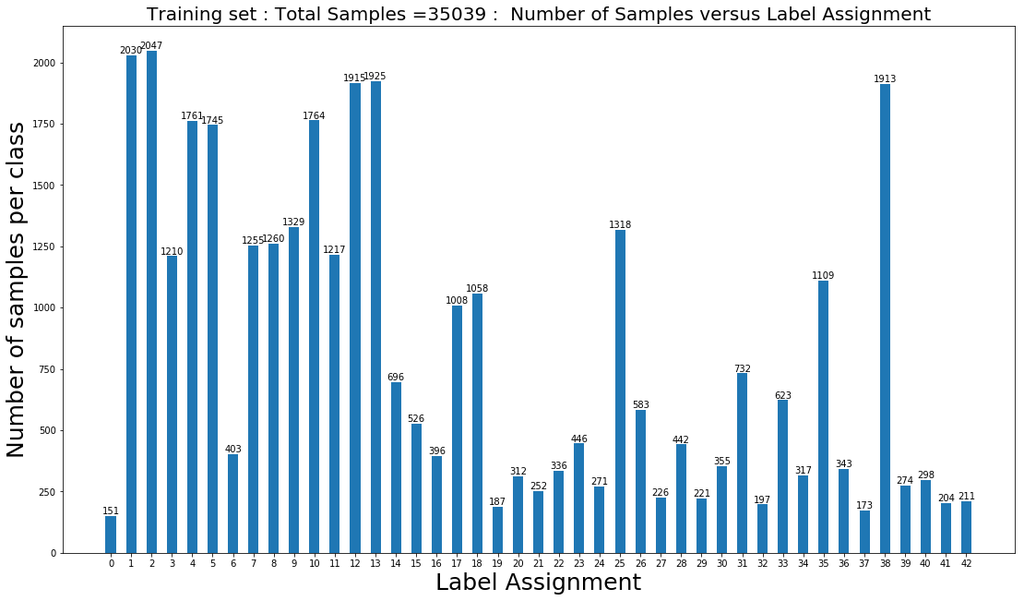

```python
Classes=np.zeros(n_classes)
for i in range(len(y_train2)):
    Classes[y_train2[i]] += 1

ind = np.arange(n_classes)
width=0.5

fig, ax = plt.subplots()
fig.set_size_inches(18.5, 10.5)
p=ax.bar(ind,Classes, width)
ax.set_xticks(range(n_classes))
ax.set_ylabel('Number of samples per class',fontsize=25)
ax.set_xlabel('Label Assignment',fontsize=25)
ax.set_title('Training set : Total Samples =' + str(y_train2.shape[0])+' :  Number of Samples versus Label Assignment',fontsize=20)
for rect in p:
    height = rect.get_height()
    ax.text(rect.get_x() +rect.get_width()/2. , height,'%d' %int(height),ha='center',va='bottom')

fig.savefig('tempImages\image3.png')

ParameterSheet.merge_range('B19:V19', "", cell_format)

ParameterSheet.write_rich_string('B19',bold,'Post Data Split into Training and validation')
ParameterSheet.insert_image('E21', 'tempImages\image3.png',{'x_scale': 0.3, 'y_scale': 0.3})
```

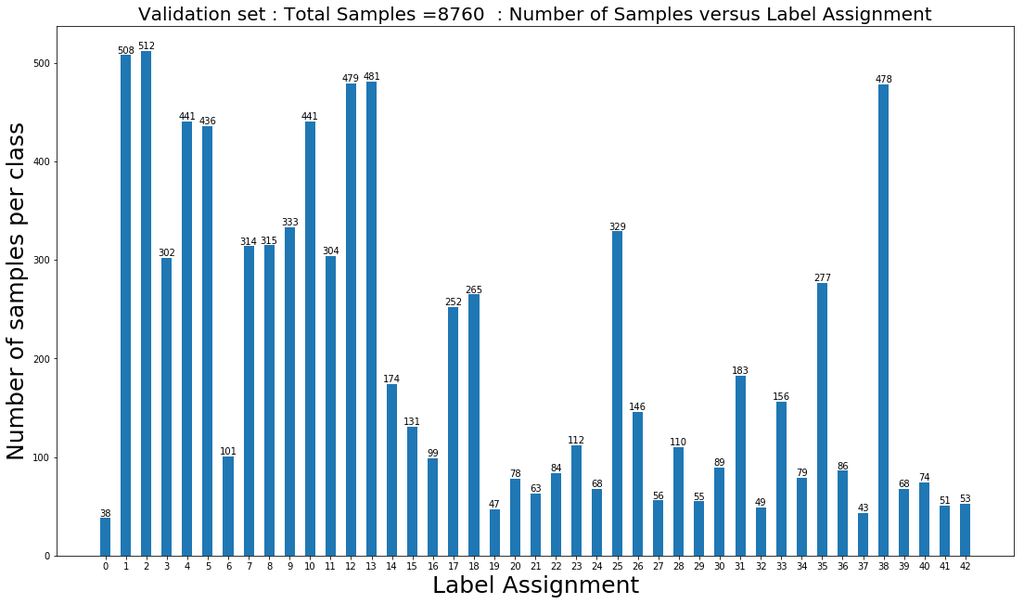

```python
Classes=np.zeros(n_classes)
for i in range(len(y_valid)):
    Classes[y_valid[i]] += 1

ind = np.arange(n_classes)
width=0.5

fig, ax = plt.subplots()
fig.set_size_inches(18.5, 10.5)
p=ax.bar(ind,Classes, width)
ax.set_xticks(range(n_classes))
ax.set_ylabel('Number of samples per class',fontsize=25)
ax.set_xlabel('Label Assignment',fontsize=25)
ax.set_title('Validation set : Total Samples =' + str(y_valid.shape[0]) + '  : Number of Samples versus Label Assignment',fontsize=20)
for rect in p:
    height = rect.get_height()
    ax.text(rect.get_x() +rect.get_width()/2. , height,'%d' %int(height),ha='center',va='bottom')
fig.savefig('tempImages\image4.png')
ParameterSheet.insert_image('N21', 'tempImages\image4.png',{'x_scale': 0.3, 'y_scale': 0.3})
```

### Model Architecture

```python
x = tf.placeholder(tf.float32, (None, 32, 32, 3))
y = tf.placeholder(tf.int32, (None))
keep_prob=tf.placeholder(tf.float32)
one_hot_y = tf.one_hot(y, n_classes)



print('done')
```

```
done
```

```python
### Define your architecture here.
### Feel free to use as many code cells as needed.


def LeNet(x):
    # Arguments used for tf.truncated_normal, randomly defines variables for the weights and biases for each layer
    mu = 0
    sigma = 0.1

    # SOLUTION: Layer 1: Convolutional. Input = 32x32x3. Output = 28x28x25.
    conv1_W = tf.Variable(tf.truncated_normal(shape=(5, 5, 3, 25), mean = mu, stddev = sigma))
    conv1_b = tf.Variable(tf.zeros(25))
    conv1   = tf.nn.conv2d(x, conv1_W, strides=[1, 1, 1, 1], padding='VALID') + conv1_b

    # SOLUTION: Activation.
    conv1 = tf.nn.relu(conv1)

    # SOLUTION: Pooling. Input = 28x28x25. Output = 14x14x25.
    conv1 = tf.nn.max_pool(conv1, ksize=[1, 2, 2, 1], strides=[1, 2, 2, 1], padding='VALID')

    # SOLUTION: Layer 2: Convolutional. Output = 10x10x50.
    conv2_W = tf.Variable(tf.truncated_normal(shape=(5, 5, 25, 50), mean = mu, stddev = sigma))
    conv2_b = tf.Variable(tf.zeros(50))
    conv2   = tf.nn.conv2d(conv1, conv2_W, strides=[1, 1, 1, 1], padding='VALID') + conv2_b

    # SOLUTION: Activation.
    conv2 = tf.nn.relu(conv2)

    # SOLUTION: Pooling. Input = 10x10x50. Output = 5x5x50.
    conv2 = tf.nn.max_pool(conv2, ksize=[1, 2, 2, 1], strides=[1, 2, 2, 1], padding='VALID')

    # SOLUTION: Flatten. Input = 5x5x50. Output = 1250.
    fc0   = flatten(conv2)

    # SOLUTION: Layer 3: Fully Connected. Input = 1250. Output = 120.
    fc1_W = tf.Variable(tf.truncated_normal(shape=(1250, 120), mean = mu, stddev = sigma))
    fc1_b = tf.Variable(tf.zeros(120))
    fc1   = tf.matmul(fc0, fc1_W) + fc1_b

    # SOLUTION: Activation.
    fc1    = tf.nn.relu(fc1)
    fc1 = tf.nn.dropout(fc1, keep_prob)

    # SOLUTION: Layer 4: Fully Connected. Input = 120. Output = 84.
    fc2_W  = tf.Variable(tf.truncated_normal(shape=(120, 84), mean = mu, stddev = sigma))
    fc2_b  = tf.Variable(tf.zeros(84))
    fc2    = tf.matmul(fc1, fc2_W) + fc2_b

    # SOLUTION: Activation.
    fc2    = tf.nn.relu(fc2)
    fc2 = tf.nn.dropout(fc2,keep_prob)

    # SOLUTION: Layer 5: Fully Connected. Input = 84. Output = 43.
    fc3_W  = tf.Variable(tf.truncated_normal(shape=(84, 43), mean = mu, stddev = sigma))
    fc3_b  = tf.Variable(tf.zeros(43))
    logits = tf.matmul(fc2, fc3_W) + fc3_b
    weights =[conv1_W,conv2_W,fc1_W,fc2_W,fc3_W]

    return logits,weights

print('done')
```

```
done
```

### Train, Validate and Test the Model

A validation set can be used to assess how well the model is performing. A low accuracy on the training and validation sets imply underfitting. A high accuracy on the training set but low accuracy on the validation set implies overfitting.

```python
### Train your model here.
### Calculate and report the accuracy on the training and validation set.
### Once a final model architecture is selected,
### the accuracy on the test set should be calculated and reported as well.
### Feel free to use as many code cells as needed.

#train pipeline
rate = 0.001

logits, weights = LeNet(x)
cross_entropy = tf.nn.softmax_cross_entropy_with_logits(logits=logits, labels=one_hot_y)
beta = 0.00001
regularizer = 0.0
for w in weights:
    regularizer += tf.nn.l2_loss(w)
loss_operation = tf.reduce_mean(cross_entropy) + beta * regularizer
optimizer = tf.train.AdamOptimizer(learning_rate = rate)
training_operation = optimizer.minimize(loss_operation)

print('done')
```

```
done
```

```python
#Evaluate
correct_prediction = tf.equal(tf.argmax(logits, 1), tf.argmax(one_hot_y, 1))
accuracy_operation = tf.reduce_mean(tf.cast(correct_prediction, tf.float32))
#saver = tf.train.Saver()

def evaluate(X_data, y_data):
    num_examples = len(X_data)
    total_accuracy = 0
    total_loss = 0
    sess = tf.get_default_session()
    for offset in range(0, num_examples, BATCH_SIZE):
        batch_x, batch_y = X_data[offset:offset+BATCH_SIZE], y_data[offset:offset+BATCH_SIZE]
        accuracy = sess.run(accuracy_operation, feed_dict={x: batch_x, y: batch_y,keep_prob:1.0})
        loss = sess.run(loss_operation, feed_dict={x: batch_x, y: batch_y,keep_prob:1.0})
        total_accuracy += (accuracy * len(batch_x))
        total_loss += (loss * len(batch_x))
    return total_accuracy / num_examples, total_loss / num_examples
print('done')
```

```
done
```

```python
config = tf.ConfigProto(allow_soft_placement = True)
config.gpu_options.per_process_gpu_memory_fraction=0.3
```

```python
#train
EPOCHS = 100
BATCH_SIZE = 50
print('done')
rowcount=1
Epochresults=[]
import time
op=time.time()
with tf.Session(config=config) as sess:
    sess.run(tf.global_variables_initializer())
    num_examples = len(X_train2)

    print("Training...")
    print()
    for i in range(EPOCHS):
        #print(gray_Image_train.shape, y_train.shape)
        X_train2, y_train2 = shuffle(X_train2, y_train2)
        for offset in range(0, num_examples, BATCH_SIZE):
            end = offset + BATCH_SIZE
            batch_x, batch_y = X_train2[offset:end], y_train2[offset:end]
            #print(batch_x.shape,batch_y.shape)
            sess.run(training_operation, feed_dict={x: batch_x, y: batch_y,keep_prob:0.75})
        training_accuracy,training_loss = evaluate(X_train2, y_train2)
        validation_accuracy,validation_loss = evaluate(X_valid, y_valid)
        print("EPOCH {} ...".format(i+1))
        print("Validation Accuracy = {:.3f} Validation loss = {:.3f} ".format(validation_accuracy,validation_loss))
        print("Training Accuracy = {:.3f}  Training loss = {:.3f}".format(training_accuracy,training_loss))
        print()
        Epochresults.append([(i+1), validation_accuracy,validation_loss, training_accuracy,training_loss,time.time()])
        if i%1==0:
            NNSheet.write_rich_string('A'+str(rowcount),"EPOCH {} ...".format(i+1))
            NNSheet.write_rich_string('B'+str(rowcount),"Validation Accuracy = {:.3f}".format(validation_accuracy))
            NNSheet.write_rich_string('C'+str(rowcount),"Validation Loss = {:.3f}".format(validation_loss))
            NNSheet.write_rich_string('D'+str(rowcount),"Training Accuracy = {:.3f}".format(training_accuracy))
            NNSheet.write_rich_string('E'+str(rowcount),"Training Loss = {:.3f}".format(training_loss))
            rowcount+=1
    saver = tf.train.Saver()
    save_path = saver.save(sess, "Modelsaver/model.ckpt")
    print("Model saved in file: %s" % save_path)

print(op-time.time())
```

```
done
Training...

EPOCH 1 ...
Validation Accuracy = 0.545 Validation loss = 1.500
Training Accuracy = 0.558  Training loss = 1.462

EPOCH 2 ...
Validation Accuracy = 0.760 Validation loss = 0.785
Training Accuracy = 0.783  Training loss = 0.708

EPOCH 3 ...
Validation Accuracy = 0.851 Validation loss = 0.506
Training Accuracy = 0.881  Training loss = 0.406

EPOCH 4 ...
Validation Accuracy = 0.893 Validation loss = 0.383
Training Accuracy = 0.923  Training loss = 0.275

EPOCH 5 ...
Validation Accuracy = 0.903 Validation loss = 0.352
Training Accuracy = 0.938  Training loss = 0.220

EPOCH 6 ...
Validation Accuracy = 0.924 Validation loss = 0.276
Training Accuracy = 0.963  Training loss = 0.146

EPOCH 7 ...
Validation Accuracy = 0.931 Validation loss = 0.258
Training Accuracy = 0.972  Training loss = 0.116

EPOCH 8 ...
Validation Accuracy = 0.938 Validation loss = 0.238
Training Accuracy = 0.976  Training loss = 0.100

EPOCH 9 ...
Validation Accuracy = 0.939 Validation loss = 0.228
Training Accuracy = 0.978  Training loss = 0.094

EPOCH 10 ...
```

[output cut: 350 more lines]

```

EPOCH 98 ...
Validation Accuracy = 0.952 Validation loss = 0.298
Training Accuracy = 0.992  Training loss = 0.067

EPOCH 99 ...
Validation Accuracy = 0.966 Validation loss = 0.236
Training Accuracy = 0.999  Training loss = 0.045

EPOCH 100 ...
Validation Accuracy = 0.971 Validation loss = 0.212
Training Accuracy = 0.999  Training loss = 0.042

Model saved in file: Modelsaver/model.ckpt
-3970.09299993515
```

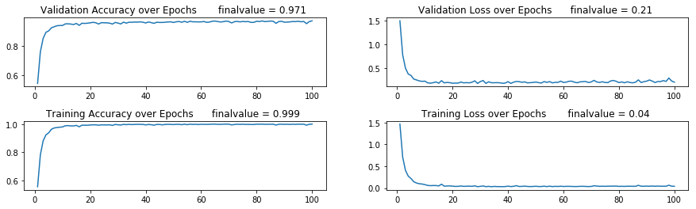

```python
EpochNumber = np.asarray(Epochresults)[:,0]
VA=np.asarray(Epochresults)[:,1]
VL=np.asarray(Epochresults)[:,2]
TA=np.asarray(Epochresults)[:,3]
TL=np.asarray(Epochresults)[:,4]
timeTicks=np.asarray(Epochresults)[:,5]

plt.figure(figsize=(15,4))

plt.subplot(221)
plt.plot(EpochNumber,VA)
plt.title('Validation Accuracy over Epochs       finalvalue = {:.3f} ' .format(VA[len(VA)-1]))

plt.subplot(222)
plt.plot(EpochNumber,VL)
plt.title('Validation Loss over Epochs      finalvalue = {:.2f} ' .format(VL[len(VL)-1]))

plt.subplot(223)
plt.plot(EpochNumber,TA)
plt.title('Training Accuracy over Epochs      finalvalue = {:.3f} ' .format(TA[len(TA)-1]))

plt.subplot(224)
plt.plot(EpochNumber,TL)
plt.title('Training Loss over Epochs       finalvalue = {:.2f} ' .format(TL[len(TL)-1]))

plt.subplots_adjust(hspace=.5)
plt.savefig('tempImages\image5.png')


NNSheet.insert_image('L4', 'tempImages\image5.png',{'x_scale': 0.3, 'y_scale': 0.3})
book.close()
```

## Step 3: Test a Model on New Images

To give yourself more insight into how your model is working, download at least five pictures of German traffic signs from the web and use your model to predict the traffic sign type.

You may find `signnames.csv` useful as it contains mappings from the class id (integer) to the actual sign name.

### Load and Output the Images

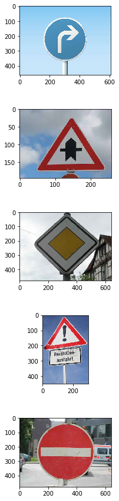

```python
### Load the images and plot them here.
### Feel free to use as many code cells as needed.

import os
import matplotlib.image as mpimg
from skimage.transform import resize

filenames = os.listdir("New_images/")
plt.figure(figsize=(15,15))
plt.subplots_adjust(hspace=0.5)
new_images=[]
for i,j in enumerate(filenames):
    new_images.append(mpimg.imread("New_images/"+j))
n=len(new_images)
resized_images=[]

for i,j in enumerate(new_images):
    plt.subplot(n,1,i+1)
    #resized_images.append(resize(j, (32, 32)))
    plt.imshow(j)
```

### Predict the Sign Type for Each Image

```python
### Calculate the accuracy for these 5 new images.
### For example, if the model predicted 1 out of 5 signs correctly, it's 20% accurate on these new images.
```

[output not shown]

### Output Top 5 Softmax Probabilities For Each Image Found on the Web

```python
### Print out the top five softmax probabilities for the predictions on the German traffic sign images found on the web.
### Feel free to use as many code cells as needed.
```

```
INFO:tensorflow:Restoring parameters from Modelsaver/model.ckpt
Model restored.

Predicted Class:   General caution           Class Confidence: 0.673979
Predicted Class:   Traffic signals           Class Confidence: 0.201113
Predicted Class:   Right-of-way at the next intersection           Class Confidence: 0.103295
Predicted Class:   Road work           Class Confidence: 0.0127792
Predicted Class:   Pedestrians           Class Confidence: 0.0071179
```

```
INFO:tensorflow:Restoring parameters from Modelsaver/model.ckpt
Model restored.

Predicted Class:   Right-of-way at the next intersection           Class Confidence: 1.0
Predicted Class:   Beware of ice/snow           Class Confidence: 3.16953e-25
Predicted Class:   Traffic signals           Class Confidence: 9.06876e-26
Predicted Class:   Road work           Class Confidence: 4.84408e-26
Predicted Class:   Pedestrians           Class Confidence: 7.38746e-27




INFO:tensorflow:Restoring parameters from Modelsaver/model.ckpt
Model restored.

Predicted Class:   Priority road           Class Confidence: 1.0
Predicted Class:   Speed limit (20km/h)           Class Confidence: 0.0
Predicted Class:   Speed limit (30km/h)           Class Confidence: 0.0
Predicted Class:   Speed limit (50km/h)           Class Confidence: 0.0
Predicted Class:   Speed limit (60km/h)           Class Confidence: 0.0




INFO:tensorflow:Restoring parameters from Modelsaver/model.ckpt
Model restored.

Predicted Class:   Speed limit (120km/h)           Class Confidence: 0.418383
Predicted Class:   Speed limit (70km/h)           Class Confidence: 0.349812
Predicted Class:   Speed limit (100km/h)           Class Confidence: 0.231421
Predicted Class:   Wild animals crossing           Class Confidence: 0.000302915
Predicted Class:   Traffic signals           Class Confidence: 3.76852e-05




INFO:tensorflow:Restoring parameters from Modelsaver/model.ckpt
Model restored.

Predicted Class:   No entry           Class Confidence: 1.0
Predicted Class:   Stop           Class Confidence: 3.06562e-26
Predicted Class:   Bumpy road           Class Confidence: 3.43033e-28
Predicted Class:   No passing           Class Confidence: 5.0107e-29
Predicted Class:   Priority road           Class Confidence: 9.50505e-30




-24476.09549999237
```

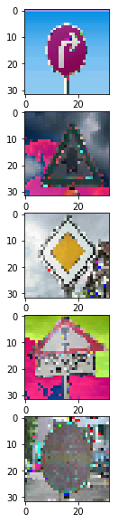

```python
### Run the predictions here and use the model to output the prediction for each image.
### Make sure to pre-process the images with the same pre-processing pipeline used earlier.
### Feel free to use as many code cells as needed.
imagecount=1
plt.figure(figsize=(25,10))
for i,j in enumerate(new_images):
    with tf.Session(config=config) as sess:
        sess.run(tf.global_variables_initializer())
        saver.restore(sess, "Modelsaver/model.ckpt")
        print("Model restored.")
        print("   ")
        [h,w,l]=j.shape
        j=np.reshape(j,(1,h,w,l))
        New_img = Normalize(j)
        New_img=resize(New_img[0], (32, 32))
        Test_Prediction = tf.nn.softmax(logits)
        classification = sess.run(Test_Prediction,feed_dict = {x: [New_img],keep_prob:1})
        Test_Class = sess.run(tf.argmax(classification,1))
        value,indices = sess.run(tf.nn.top_k(tf.constant(classification), k=5))

        for k,l in enumerate(value[0]):
            predicted_class = Sign[indices[0,k]]
            print("Predicted Class:   " +predicted_class +"           Class Confidence: "+str(l))
        plt.subplot(5,1,imagecount)
        plt.imshow(New_img)
        print(" ")
        print(" ")
        print(" ")
        print(" ")
        imagecount+=1
plt.savefig("finaltest.png")
print(op-time.time())
```

### Project Writeup

Once you have completed the code implementation, document your results in a project writeup using this [template](https://github.com/udacity/CarND-Traffic-Sign-Classifier-Project/blob/master/writeup_template.md) as a guide. The writeup can be in a markdown or pdf file.

```python
### Visualize your network's feature maps here.
### Feel free to use as many code cells as needed.

# image_input: the test image being fed into the network to produce the feature maps
# tf_activation: should be a tf variable name used during your training procedure that represents the calculated state of a specific weight layer
# activation_min/max: can be used to view the activation contrast in more detail, by default matplot sets min and max to the actual min and max values of the output
# plt_num: used to plot out multiple different weight feature map sets on the same block, just extend the plt number for each new feature map entry

def outputFeatureMap(image_input, tf_activation, activation_min=-1, activation_max=-1 ,plt_num=1):
    # Here make sure to preprocess your image_input in a way your network expects
    # with size, normalization, ect if needed
    # image_input =
    # Note: x should be the same name as your network's tensorflow data placeholder variable
    # If you get an error tf_activation is not defined it may be having trouble accessing the variable from inside a function
    activation = tf_activation.eval(session=sess,feed_dict={x : image_input})
    featuremaps = activation.shape[3]
    plt.figure(plt_num, figsize=(15,15))
    for featuremap in range(featuremaps):
        plt.subplot(6,8, featuremap+1) # sets the number of feature maps to show on each row and column
        plt.title('FeatureMap ' + str(featuremap)) # displays the feature map number
        if activation_min != -1 & activation_max != -1:
            plt.imshow(activation[0,:,:, featuremap], interpolation="nearest", vmin =activation_min, vmax=activation_max, cmap="gray")
        elif activation_max != -1:
            plt.imshow(activation[0,:,:, featuremap], interpolation="nearest", vmax=activation_max, cmap="gray")
        elif activation_min !=-1:
            plt.imshow(activation[0,:,:, featuremap], interpolation="nearest", vmin=activation_min, cmap="gray")
        else:
            plt.imshow(activation[0,:,:, featuremap], interpolation="nearest", cmap="gray")

print(new_images[0].shape)
outputFeatureMap(Normalize([new_images[0]]),conv1_W)
```

```
(460, 612, 3)
```

[output not shown]

Unable to get the above to work